# Ensemble Tree Methods

# Ensemble Methods

[Back to Homepage](https://alexisidlettewilson.github.io/)

Ensemble decision tree methods improve upon simple decision trees by averaging the outcomes of many decision trees. By taking the average of many models, we reduce variance and typically improve the prediction error rate.

install.packages(“MASS”)

install.packages(“randomForest”)

library(MASS)

library(randomForest)

The data set is Housing Values in Suburbs of Boston. There are 506 observations and 14 features.

```r
data(Boston)
?Boston
```

## Random Forest

Create a training data set using 300 of the 506 observations.

```r
set.seed(101)
train <- sample(1:nrow(Boston),300)
```

Use the *randomForest* function to generate the random forest model using the training set. The target variable is `medv`, the median home value of owner-occupied homes.

```r
rf.Boston = randomForest(medv~., data=Boston, subset=train)
rf.Boston
```

```
Call:
 randomForest(formula = medv ~ ., data = Boston, subset = train)
               Type of random forest: regression
                     Number of trees: 500
No. of variables tried at each split: 4

          Mean of squared residuals: 12.30718
                    % Var explained: 85.13
```

Create two vector variables to hold out-of-bag error and test error for each model.

```r
oob.err <- double(13)
test.err <- double(13)
```

*mtry* is a parameter of the randomForest function corresponding to the number of features to randomly select. We create a loop that will fit models using 1, 2, 3 randomly selected features for each split, up to 13 which is all the features.

Four hundred trees will be created for each value of *mtry*.

For each value of *mtry* the average Mean Squared Error (MSE) will be captured in the `oob.err` variable.

We then predict the values of `medv` for the observations not in the training set.

For each value of *mtry* the Residual Squared Error (RSS) will be captured in the `test.err` variable.

Finally, the values of *mtry* are printed out just to show the loop functioned.

```r
for (mtry in 1:13) {
  fit <- randomForest(medv~., data=Boston, subset=train, mtry = mtry, ntree=400)
  oob.err[mtry] <- fit$mse[400]
  pred <- predict(fit, Boston[-train,])
  test.err[mtry] <- with(Boston[-train,], mean((medv-pred)^2))
  cat(mtry," ")
}
```

```
1  2  3  4  5  6  7  8  9  10  11  12  13
```

We plot the MSE and RSS for each value of *mtry* using the *matplot* function.

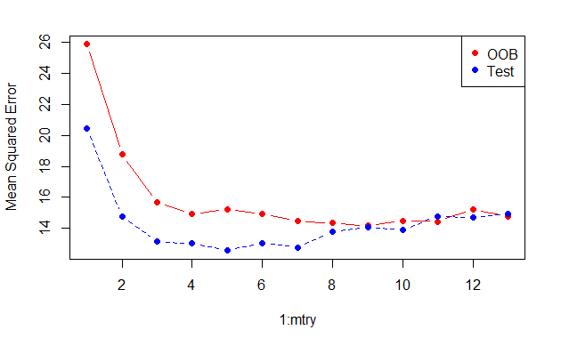

```r
matplot(1:mtry, cbind(test.err,oob.err), pch=19, col=c("red","blue"), type="b", ylab="Mean Squared Error")
legend("topright", legend=c("OOB", "Test"), pch=19, col=c("red","blue"))
```

## Boosting an Ensemble Decision Tree Method

Boosting is very similar to random forest, except that each new tree seeks to improve upon the performance of the previous tree. The trees are created sequentially and are shallow, possibly limited to two or four terminal nodes. Boosting reduces bias in a model helping it perform better on test data.

Boosting may be performed with the `gbm` package, Gradient Boosted Machines.

```r
require(gbm)
```

There are three tuning parameters for boosting.

1. The number of trees
2. The shrinkage parameter *lambda*
3. The number of splits allowed for each tree

Call gbm to create 10,000 trees. We pick an arbitrary value for lambda - 0.01, labeled shrinkage. Interaction depth indicates the number of splits. We limit each tree to four splits. The distribution is set based on the loss function of the algorithm. Ours is Gaussian because we are measuring success based on squared error.

|  | var | rel.inf |
| --- | --- | --- |
| rm | rm | 36.2089680 |
| lstat | lstat | 31.0739145 |
| dis | dis | 7.9407769 |
| crim | crim | 5.5632078 |
| nox | nox | 4.6269664 |
| ptratio | ptratio | 4.0158796 |
| black | black | 3.0952699 |
| age | age | 3.0575362 |
| tax | tax | 1.4711289 |
| chas | chas | 1.3706159 |

[output cut: 3 more lines]

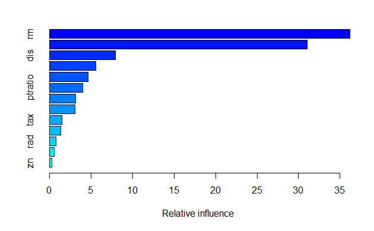

```r
boost.boston <- gbm(medv~., data = Boston[train,], distribution = "gaussian", n.trees=10000, shrinkage = 0.01, interaction.depth=4)
summary(boost.boston)
```

The summary output is a variable importance plot. The number of rooms and the percentage of “low status” people appear to be the most important predictors of `medv`.

We can plot the relationships between `medv` and each variable from the boosting object.

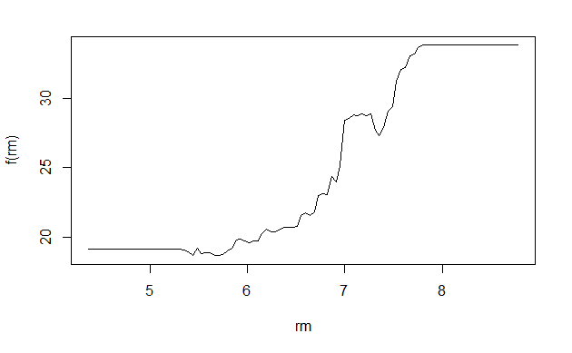

```r
plot(boost.boston, i="rm")
```

We can see that as the number of rooms increases, `medv` (as a function of rm) increases, especially after seven rooms.

Finally, we will predict values from the test data set using the boosted model.

```r
n.trees = seq(from=100, to=10000, by=100)
predmat = predict(boost.boston, newdata = Boston[-train,], n.trees=n.trees)
dim(predmat)
```

```
[1] 206 100
```

[figure not shown]

```r
berr = with(Boston[-train,], apply( (predmat-medv)^2,2,mean) )
plot(n.trees, berr, pch=19, ylab="Mean Squared Error", xlab="# Trees", main="Boosting Test Error")
abline(h=min(test.err), col="green")
```

We see that the boosted model reduces the test error significantly but after ~3,000 trees, the effect is minimized the the error flattens out.